# Estimator explaination

Cherubael

## Описание исходных данных

Исходные данные имеют следующий вид:

| session | time | name | E | size | n | r | ln | iter | citer | duration | mark | bank | tick | datetime |
| --- | --- | --- | --- | --- | --- | --- | --- | --- | --- | --- | --- | --- | --- | --- |
| 1541094228907 | 1541094228 | Иванов, И.И.,муж,25 | 1 | 8 | 6 | 12 | 1 | 0 | 0 | 88 | pump | 0 | 0 | 19:43:48 |
| 1541094228907 | 1541094228 | Иванов, И.И.,муж,25 | 1 | 8 | 7 | 12 | 1 | 1 | 1 | 101 | pump | 0 | 209 | 19:43:48 |
| 1541094228907 | 1541094229 | Иванов, И.И.,муж,25 | 1 | 8 | 8 | 14 | 1 | 2 | 2 | 73 | exploded | 0 | 189 | 19:43:49 |
| 1541094228907 | 1541094229 | Иванов, И.И.,муж,25 | 1 | 128 | 59 | 10 | 2 | 3 | 0 | 0 | pump | 0 | 301 | 19:43:49 |
| 1541094228907 | 1541094229 | Иванов, И.И.,муж,25 | 1 | 128 | 60 | 12 | 2 | 4 | 1 | 82 | pump | 0 | 560 | 19:43:49 |
| 1541094228907 | 1541094230 | Иванов, И.И.,муж,25 | 1 | 128 | 61 | 14 | 2 | 5 | 2 | 92 | pump | 0 | 175 | 19:43:50 |

где:

- *session* - идетификатор сессии исследования, равный времени начала теста,
- *time* - текущее время, в которое произошло прикосновение к экрану,
- *name* - идетификатор испытуемого,
- *E* - последовательный номер попытки,
- *size* - максимальный размер шара (по умолчанию красный шар имеет размер равный 8, желтый шар имеет размер равный 32, зеленый шар имеет размер равный 128),
- *n* - текущий размер шара,
- *r* - радиус шара,
- *ln* - идентификатор текущего шара,
- *iter* - идетификатор касания в пределах всех трех попыток,
- *citer* - идетификатор касания для текущей попытки,
- *duration* - продолжительность касания,
- *mark* - метка действия (накачка шара, взрыв или сохранение денег в банк),
- *bank* - количество денег, сохраненных в банке,
- *tick* - количество миллисекунд, прошедших с прошедшего касания,
- *datetime* - текущее время в человекочитаемом формате.

# Интервал между касаниями

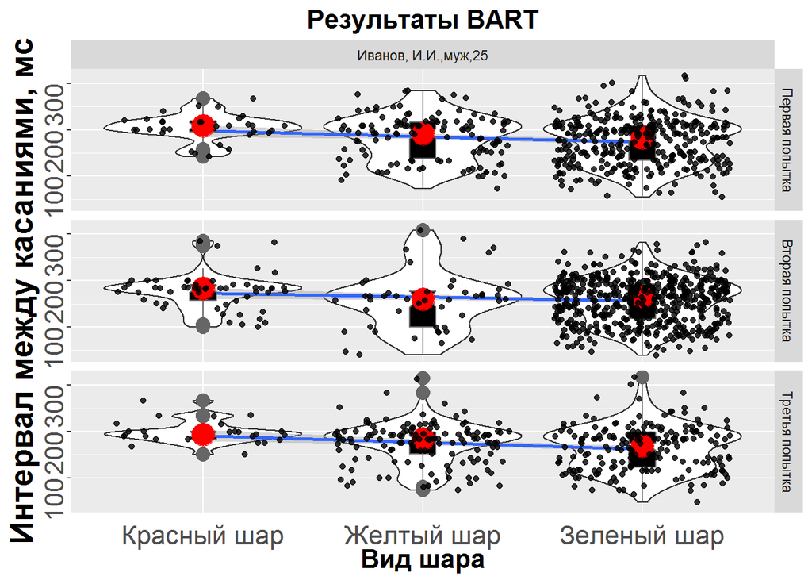

Результаты представлены как усредненное время интервалов между касаниями для каждого из видов шаров (красный, желтый, зеленый) в каждой из попыток:

|  | Красный шар | Желтый шар | Зеленый шар |
| --- | --- | --- | --- |
| Первая попытка | 243.1538 | 192.7803 | 177.0172 |
| Вторая попытка | 316.4231 | 350.3509 | 198.3614 |
| Третья попытка | 281.1220 | 206.4797 | 179.3284 |

Также расчитывается стандартизованное (при помощи Z-преобразования) время интервалов между касаниями для каждого из шаров в каждой из попыток:

|  | Красный шар | Желтый шар | Зеленый шар |
| --- | --- | --- | --- |
| Первая попытка | -3.876996e-17 | 1.171267e-18 | -4.818406e-17 |
| Вторая попытка | 5.409752e-17 | -9.832477e-18 | -1.116719e-17 |
| Третья попытка | -1.676547e-18 | -6.118014e-17 | -1.382491e-16 |

# Продолжительность касания

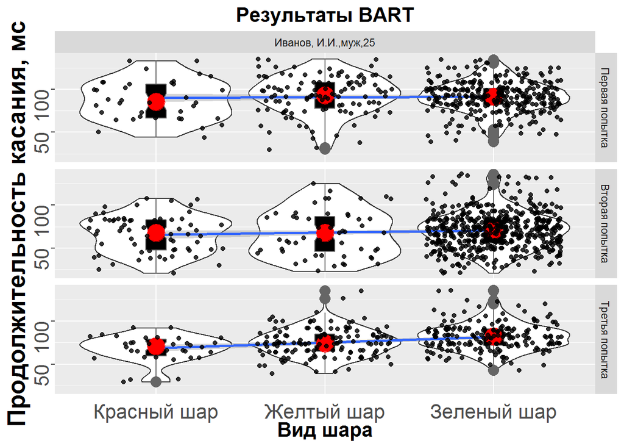

Результаты представлены как усредненная продолжительность касания для каждого из видов шаров (красный, желтый, зеленый) в каждой из попыток:

|  | Красный шар | Желтый шар | Зеленый шар |
| --- | --- | --- | --- |
| Первая попытка | 85.38462 | 98.31818 | 94.04023 |
| Вторая попытка | 64.16667 | 66.43860 | 71.59392 |
| Третья попытка | 56.85366 | 74.87162 | 80.61765 |

Также расчитывается стандартизованное (при помощи Z-преобразования) продолжительность касания для каждого из шаров в каждой из попыток:

|  | Красный шар | Желтый шар | Зеленый шар |
| --- | --- | --- | --- |
| Первая попытка | -8.461781e-17 | 1.352312e-16 | 5.695800e-18 |
| Вторая попытка | -1.346176e-16 | 4.605386e-17 | 9.994055e-17 |
| Третья попытка | 7.723751e-17 | -2.502884e-16 | -2.751907e-16 |

# Скорость касания (отношение интервала между касаниями к их продолжительности)

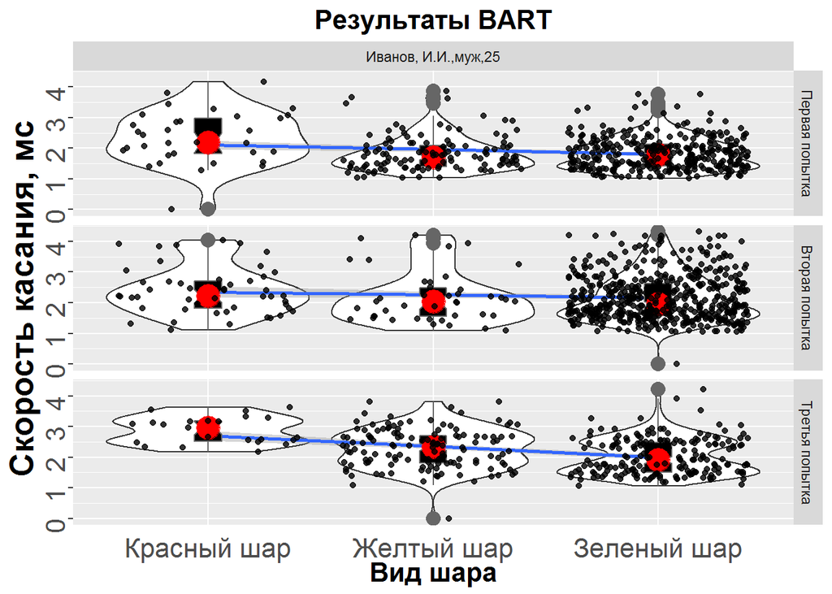

Результаты представлены как усредненная скорость касания (отношение интервала между касаниями к их продолжительности) для каждого из видов шаров (красный, желтый, зеленый) в каждой из попыток:

|  | Красный шар | Желтый шар | Зеленый шар |
| --- | --- | --- | --- |
| Первая попытка | 3.147861 | 2.185209 | Inf |
| Вторая попытка | 7.061100 | 6.619580 | 3.538632 |
| Третья попытка | 5.759515 | 2.911820 | 2.287536 |

Также результаты выражаются как коэффициент корреляции (по методу Спирмена) между интервалом между касаниями и их продолжительностью для каждого из видов шаров (красный, желтый, зеленый) в каждой из попыток:

|  | Красный шар | Желтый шар | Зеленый шар |
| --- | --- | --- | --- |
| Первая попытка | -0.2145174 | 0.4277343 | 0.5104797 |
| Вторая попытка | 0.0044763 | 0.5132076 | 0.3599060 |
| Третья попытка | 0.4878796 | 0.3723697 | 0.4219945 |

# Доля взорвавшихся и сохраненных шаров

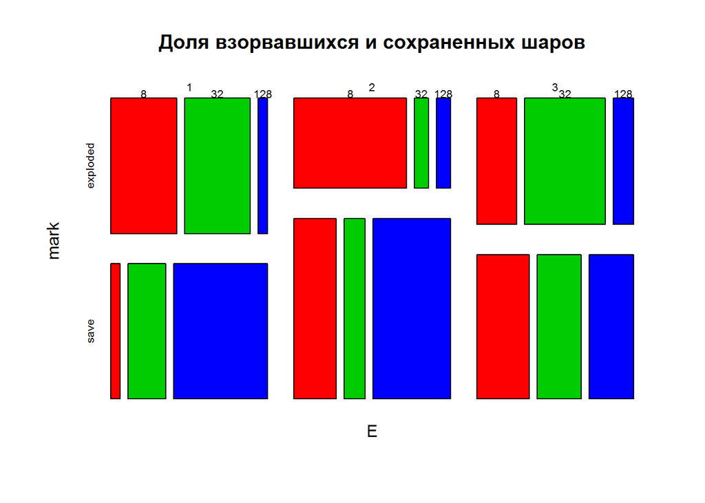

Результаты представлены как доля сохраненных шаров для каждого из видов шаров (красный, желтый, зеленый) в каждой из попыток:

|  | Красный шар | Желтый шар | Зеленый шар |
| --- | --- | --- | --- |
| Первая попытка | 0.1250000 | 0.3636364 | 0.9090909 |
| Вторая попытка | 0.4285714 | 0.7500000 | 0.9166667 |
| Третья попытка | 0.6000000 | 0.3846154 | 0.7142857 |

# Продолжительность страйков (последовательных взрывов или сохранений)

Расчитывается усредненное количество страйков взорвавшихся и сохраненных шаров по 3 этапам:

|  | Первая попытка | Вторая попытка | Третья попытка | Суммарно |
| --- | --- | --- | --- | --- |
| Взорвано | 2.5 | 1.666667 | 1.750000 | 1.95000 |
| Сохранено | 2.5 | 2.857143 | 2.285714 | 2.68421 |

# Результаты

Итоговый объект, содержащий результаты имеет следующий вид:

| Показатель | Численное значение |
| --- | --- |
| session | 1541094228907 |
| name | Иванов, И.И.,муж,25 |
| interval.H1 | 243.1538 |
| interval.H2 | 316.4231 |
| interval.H3 | 281.122 |
| interval.M1 | 192.7803 |
| interval.M2 | 350.3509 |
| interval.M3 | 206.4797 |
| interval.L1 | 177.0172 |
| interval.L2 | 198.3614 |
| interval.L3 | 179.3284 |
| interval.std.H1 | -3.876996e-17 |
| interval.std.H2 | 5.409752e-17 |
| interval.std.H3 | -1.676547e-18 |
| interval.std.M1 | 1.171267e-18 |
| interval.std.M2 | -9.832477e-18 |
| interval.std.M3 | -6.118014e-17 |
| interval.std.L1 | -4.818406e-17 |
| interval.std.L2 | -1.116719e-17 |
| interval.std.L3 | -1.382491e-16 |
| duration.H1 | 85.38462 |
| duration.H2 | 64.16667 |
| duration.H3 | 56.85366 |
| duration.M1 | 98.31818 |
| duration.M2 | 66.4386 |
| duration.M3 | 74.87162 |
| duration.L1 | 94.04023 |
| duration.L2 | 71.59392 |
| duration.L3 | 80.61765 |
| duration.std.H1 | -8.461781e-17 |
| duration.std.H2 | -1.346176e-16 |
| duration.std.H3 | 7.723751e-17 |
| duration.std.M1 | 1.352312e-16 |
| duration.std.M2 | 4.605386e-17 |
| duration.std.M3 | -2.502884e-16 |
| duration.std.L1 | 5.6958e-18 |
| duration.std.L2 | 9.994055e-17 |
| duration.std.L3 | -2.751907e-16 |
| speed.H1 | 3.147861 |
| speed.H2 | 7.0611 |
| speed.H3 | 5.759515 |
| speed.M1 | 2.185209 |
| speed.M2 | 6.61958 |
| speed.M3 | 2.91182 |
| speed.L1 | Inf |
| speed.L2 | 3.538632 |
| speed.L3 | 2.287536 |
| speed.cor.H1 | -0.2145174 |
| speed.cor.H2 | 0.004476327 |
| speed.cor.H3 | 0.4878796 |
| speed.cor.M1 | 0.4277343 |
| speed.cor.M2 | 0.5132076 |
| speed.cor.M3 | 0.3723697 |
| speed.cor.L1 | 0.5104797 |
| speed.cor.L2 | 0.359906 |
| speed.cor.L3 | 0.4219945 |
| save.ratio.E1 | 0.5 |
| save.ratio.E2 | 0.6666667 |
| save.ratio.E3 | 0.5333333 |
| save.ratio.H1 | 0.125 |
| save.ratio.H2 | 0.4285714 |
| save.ratio.H3 | 0.6 |
| save.ratio.M1 | 0.3636364 |
| save.ratio.M2 | 0.75 |
| save.ratio.M3 | 0.3846154 |
| save.ratio.L1 | 0.9090909 |
| save.ratio.L2 | 0.9166667 |
| save.ratio.L3 | 0.7142857 |
| seq.exploded | 1.95 |
| seq.saved | 2.684211 |
| seq.exploded.E1 | 2.5 |
| seq.saved.E1 | 2.5 |
| seq.exploded.E2 | 1.666667 |
| seq.saved.E2 | 2.857143 |
| seq.exploded.E3 | 1.75 |
| seq.saved.E3 | 2.285714 |

Также результаты могут быть для наглядности представлены в виде радиальных диаграмм (данные предварительно логарифмированы):

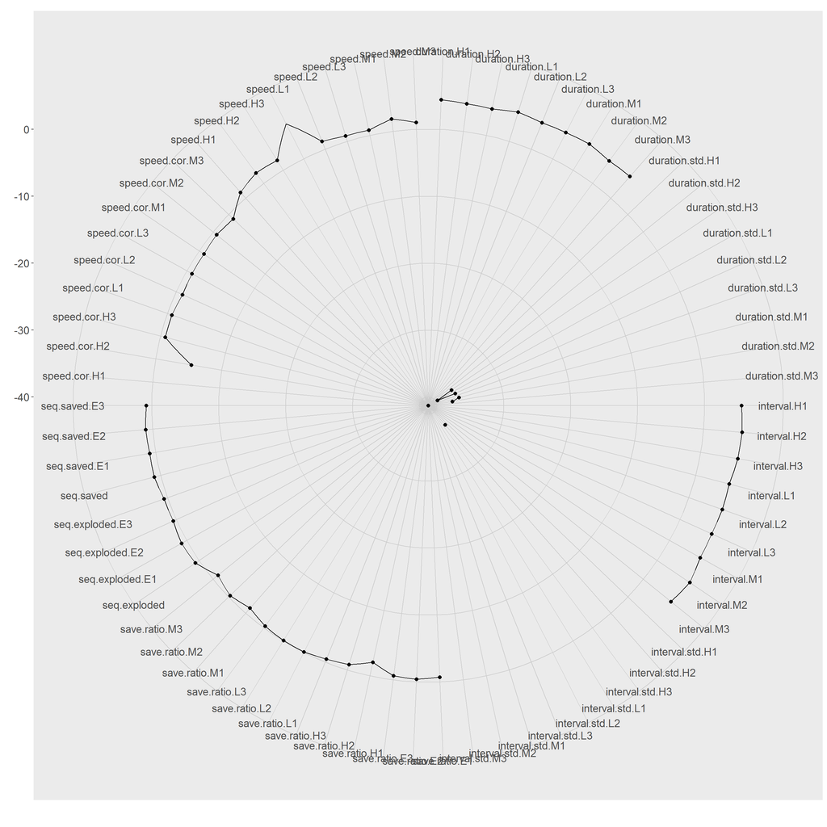